# TimeSeries_simulation_Ch1

kyung hee Kim

2021-12-10

## Ch1 Introduction

Key Finding  
1) Trend 2) abrupt changes in behavior 3) outlier

### Preliminary

```r
huron<-read.table("https://raw.githubusercontent.com/hikhloee/TS_code/main/huron.txt",header=T)
death<-read.table("https://raw.githubusercontent.com/hikhloee/TS_code/main/deaths.txt",header=T)
```

figure1.1

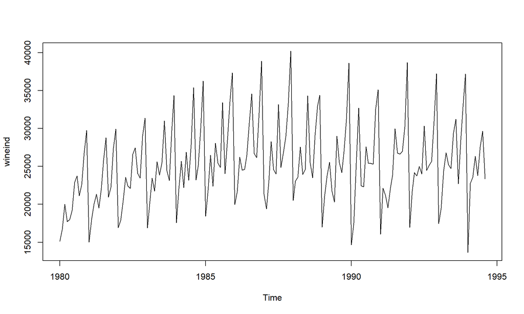

```r
plot.ts(wineind)
```

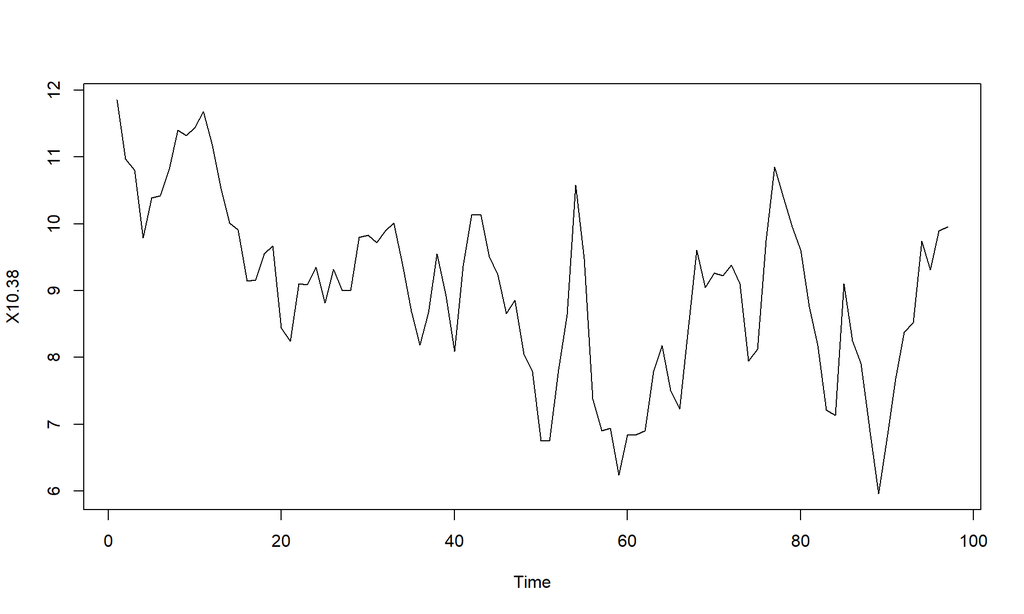

```r
plot.ts(huron)
```

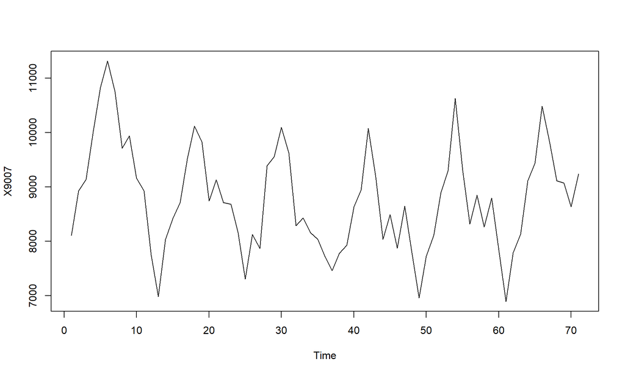

```r
plot.ts(death)
```

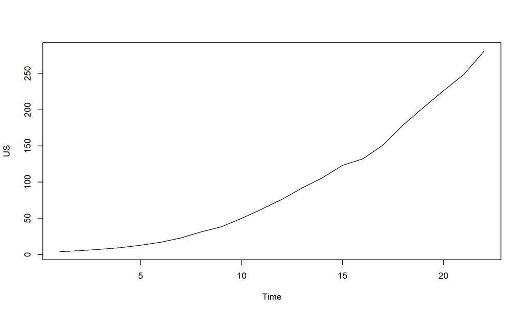

```r
US<-as.ts(USPop$population,frequency=10,start=1790)
plot.ts(US)
```

### Estimations, Elimination Trend and Seasonality

#### 1. Polynomial regression

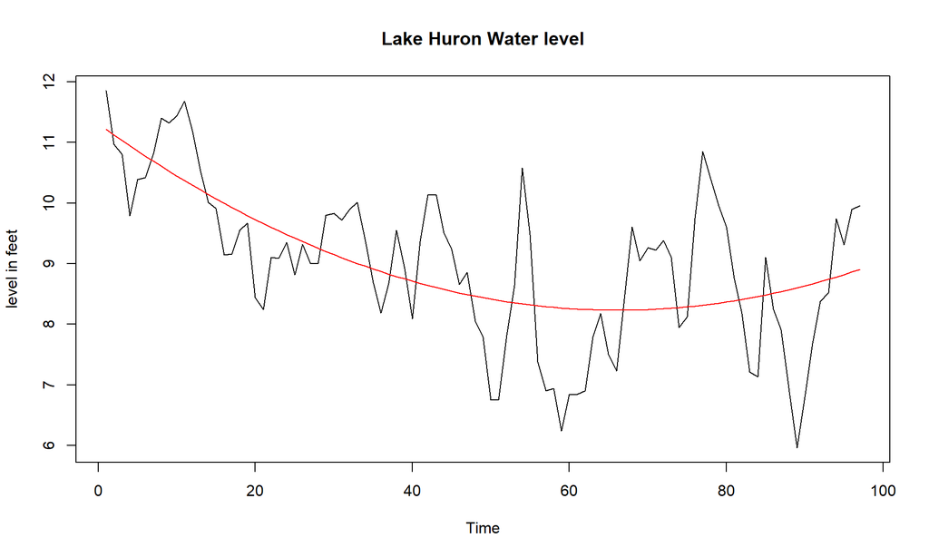

```r
n = length(huron[,1]);
x = seq(from=1, to = n, by=1)
x2 = x^2

out.lm = lm(as.matrix(huron) ~ 1 + x);
out.lm2 = lm(as.matrix(huron) ~ 1 + x + x2)

plot.ts(huron,ylab="level in feet");
title("Lake Huron Water level")
lines(x,out.lm2$fitted.values,col="red")
```

```r
test(out.lm2$residuals)
```

```
## Null hypothesis: Residuals are iid noise.
## Test                        Distribution Statistic   p-value
## Ljung-Box Q                Q ~ chisq(20)    140.49         0 *
## McLeod-Li Q                Q ~ chisq(20)     55.42         0 *
## Turning points T   (T-63.3)/4.1 ~ N(0,1)        37         0 *
## Diff signs S         (S-48)/2.9 ~ N(0,1)        50     0.484
## Rank P           (P-2328)/160.4 ~ N(0,1)      2365    0.8176
```

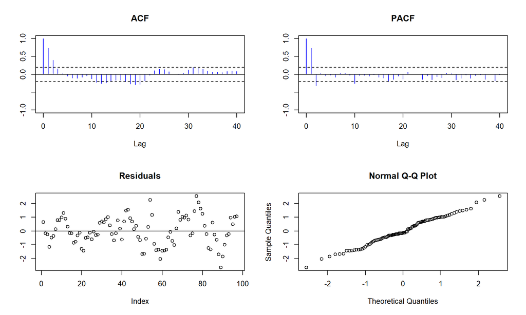

It’s available to estimate, not inference.  
To do correct inference, we need to consider dependent structure.

#### 2. Smoothing(local mean==local averaging)

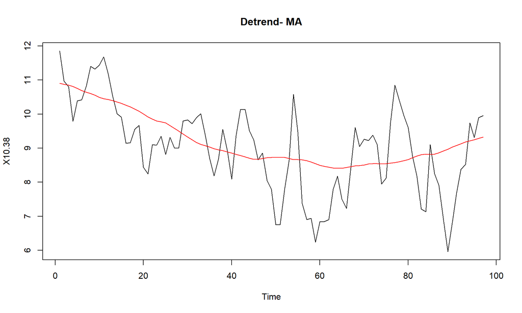

```r
huron.ma = smooth.ma(as.matrix(huron), 30) # width

plot.ts(huron)
lines(huron.ma, col="red"); title("Detrend- MA")
```

```r
#plot.ts(huron-huron.ma); title("Residuals - MA")
```

2-1. Cubic Trend smoothing  
2-2. Exponential smoothing

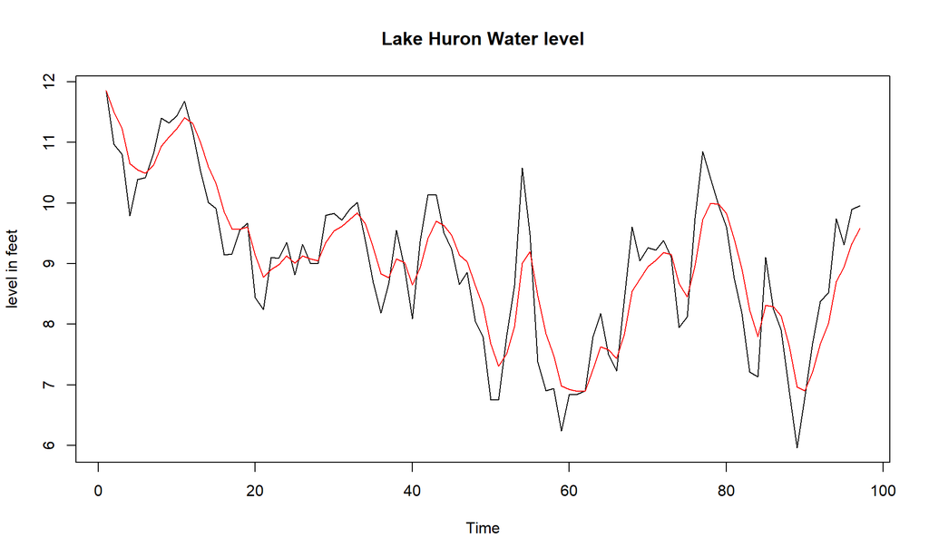

```r
huron.exp<- smooth.exp(as.matrix(huron),.4) # if it gets less, looks like a local mean.
plot.ts(huron,ylab="level in feet")
title("Lake Huron Water level")
lines(x, huron.exp,col="red")
```

2-3. multiple smooothing plot

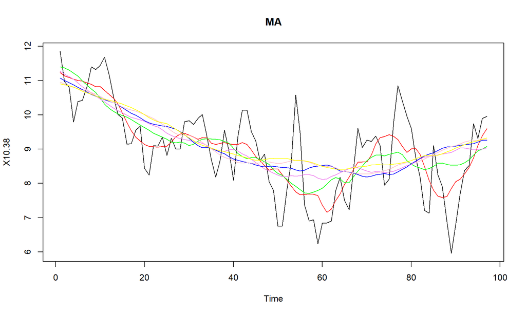

```r
huron.maq1 = smooth.ma(as.matrix(huron), 5) # width
huron.maq2 = smooth.ma(as.matrix(huron), 10) # width
huron.maq3 = smooth.ma(as.matrix(huron), 15) # width
huron.maq4 = smooth.ma(as.matrix(huron), 20) # width
huron.maq5 = smooth.ma(as.matrix(huron), 25) # width
huron.maq6 = smooth.ma(as.matrix(huron), 30)

par(mfrow=c(1,1))

plot.ts(huron);title("MA")
lines(huron.maq1, col="red")
lines(huron.maq2, col="green")
lines(huron.maq3, col="violet")
lines(huron.maq4, col="blue")
lines(huron.maq5, col="pink")
lines(huron.maq6, col="yellow")
```

```r
#idk
```

#### 3. Differencing (kills k-th order polynomial trend)

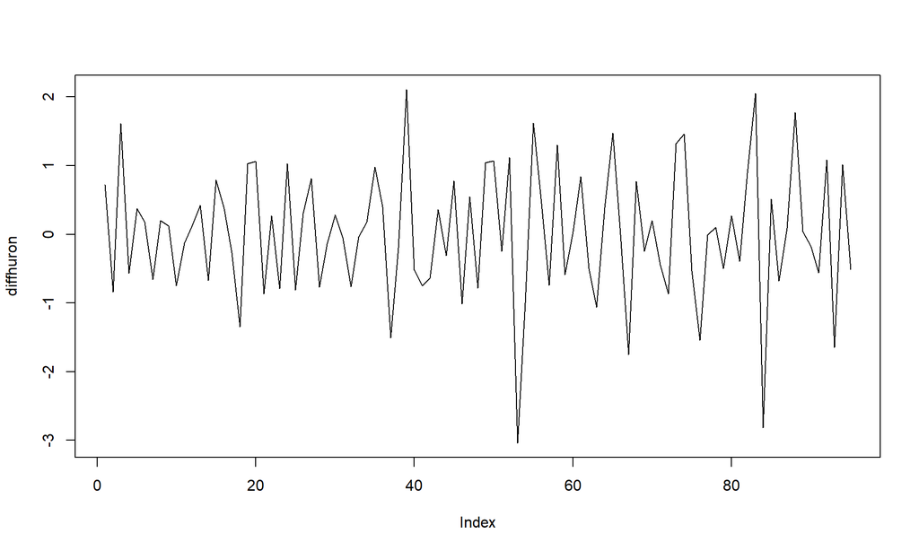

```r
huron<-as.matrix(huron)

diffhuron<-diff(diff(huron))
plot(diffhuron,type="l")
```

### Estimate Seasonality 1) Harmonic regression 2) Seasonal smoothing 3) Seasonal differencing

1. Harmonic regression  
   Select $\lambda = f_j (2\pi/n), \;f= n/d, \;f_j = j f_1$

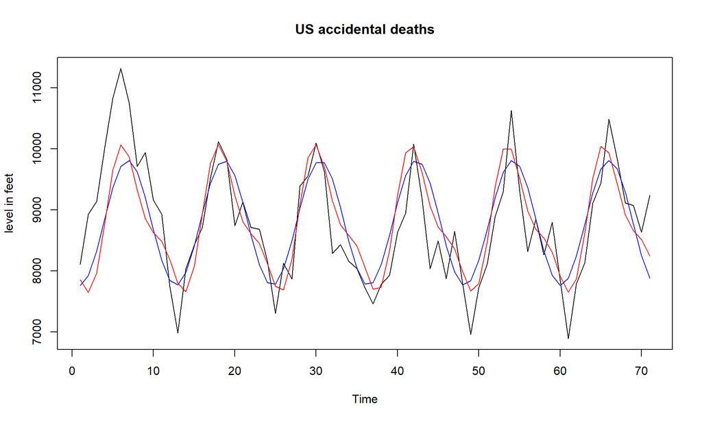

```r
death<-as.matrix(death)
n<-length(death)
t = 1:n
f1=6; f2=2*f1
costerm1 = cos(f1*2*pi/n*t)
sinterm1 = sin(f1*2*pi/n*t)
costerm2 = cos(f2*2*pi/n*t)
sinterm2 = sin(f2*2*pi/n*t)

out.lm2 = lm(death ~1+costerm1 +sinterm1) #k=1
out.lm3 = lm(death ~1+costerm1 +sinterm1+costerm2 +sinterm2) #k=2
plot.ts(death,ylab="level in feet");
title("US accidental deaths")
lines(t,out.lm2$fitted.values,col="blue")
lines(t,out.lm3$fitted.values,col="red")
```

If k gets bigger, model fits on data.

2. Seasonal smoothing

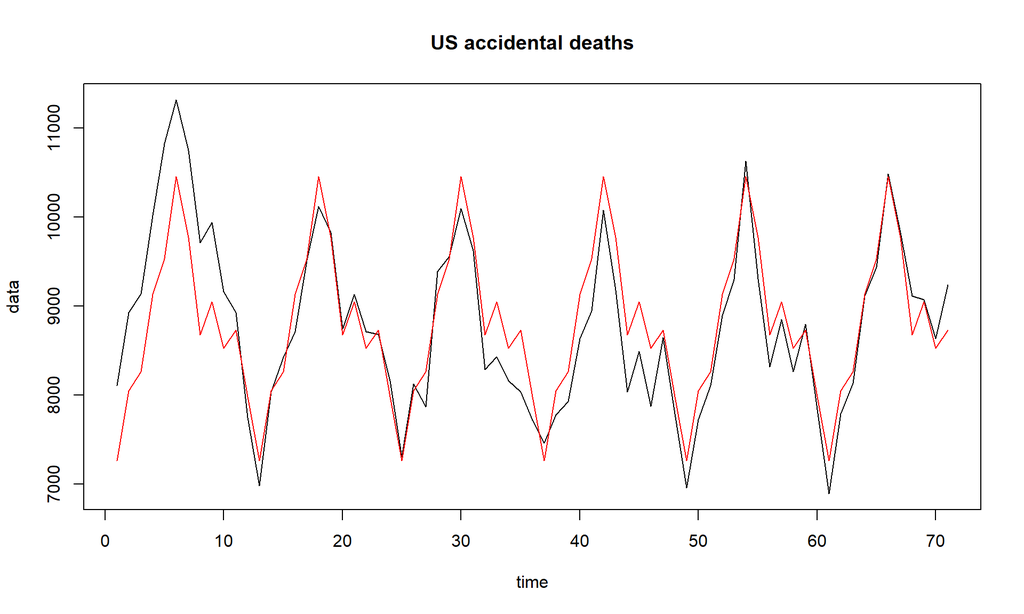

```r
season.avg = season(death,d=12)
plot.ts(death,ylab="data",xlab="time")
title("US accidental deaths")
lines(1:length(death), season.avg + mean(death), col="red")
```

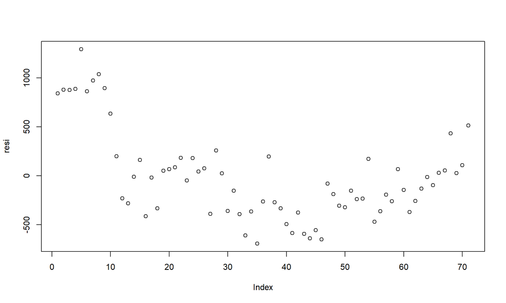

```r
resi = death - season.avg - mean(death)
plot(resi)
```

3. Seasonal differencing

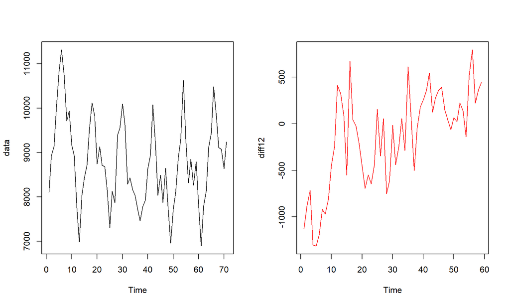

```r
diff12 = diff(death,lag=12)
par(mfrow=c(1,2))
plot.ts(death,ylab="data")
plot.ts(diff12,col="red",ylab="diff12")
```

### Estimating both trend and seasonality